# Examples of tidyverse

Tom Buonora and Shane Hylton – EXTEND

2021-11-16

```r
library(tidyverse)         # ggplot2, dplyr, tidyr, readr, tibble, sringr and more
```

# Tidyverse Vignette

## readr : read_csv()

read_csv is part of readr whereas read.csv is base R. I’m not sure that read_csv is tidier than read.csv

```r
CURR_PATH<-str_trim(getwd())


# to do : use the kaggle api
# https://www.kaggle.com/mysarahmadbhat/nyc-traffic-accidents

# nyc_traffic_accidents<-read.csv("NYC Accidents 2020.csv")

nyc_traffic_accidents <- read_csv("https://raw.githubusercontent.com/TheReallyBigApple/CunyAssignments/main/DATA607/NYC%20Accidents%202020.csv",show_col_types = FALSE)
```

## readr : spec()

the spec function displays the schema for the data frame or tibble

```r
# the readr spec method shows you the schema
spec(nyc_traffic_accidents)
# this is base R, it removes the spaces from the column names
colnames(nyc_traffic_accidents) <- make.names(colnames(nyc_traffic_accidents))
```

[output not shown]

## dplyr : group_by() dplyr_summarise() magrittr : %>%

magrittr provides several operators including the commonly used %>% which pipes results from one function to the next

```r
nyc_traffic_accidents %>%
  group_by(BOROUGH) %>%
  summarise(observations = n(), killed = sum(NUMBER.OF.PERSONS.KILLED, na.rm = TRUE))
```

```
#> # A tibble: 6 × 3
#>   BOROUGH       observations killed
#>   <chr>                <int>  <dbl>
#> 1 BRONX                 9417     10
#> 2 BROOKLYN             16907     27
#> 3 MANHATTAN             7353      9
#> 4 QUEENS               14017     20
#> 5 STATEN ISLAND         1446      6
#> 6 <NA>                 25741     72
```

### An Extension of group_by( ) using arrange ( )

Here, we can group by borough and rearrange the dataframe to make viewing the data by borough simpler.

```r
nyc_traffic_accidents <- nyc_traffic_accidents %>%
  group_by(BOROUGH) %>%
  arrange(BOROUGH)
```

## dplyr : select()

select can select certain columns select can also omit certain columns. Below I omit a sequence of columns starting with LATTITUDE and ending with LOCATION

```r
nyc_traffic_accidents<-nyc_traffic_accidents %>%
    select(!(LATITUDE:LOCATION))
```

### dplyr::relocate( ) – Extension

We can further this tidying of the dataframe by rearranging the data how we see fit.

```r
nyc_traffic_accidents<-nyc_traffic_accidents %>%
    relocate(BOROUGH, .before = CRASH.DATE)

nyc_traffic_accidents<-nyc_traffic_accidents %>%
    relocate(VEHICLE.TYPE.CODE.1, .after = BOROUGH)
nyc_traffic_accidents<-nyc_traffic_accidents %>%
    relocate(VEHICLE.TYPE.CODE.2, .after = VEHICLE.TYPE.CODE.1)

nyc_traffic_accidents<-nyc_traffic_accidents %>%
    relocate(CONTRIBUTING.FACTOR.VEHICLE.1, .after = VEHICLE.TYPE.CODE.2)
nyc_traffic_accidents<-nyc_traffic_accidents %>%
    relocate(CONTRIBUTING.FACTOR.VEHICLE.2, .after = CONTRIBUTING.FACTOR.VEHICLE.1)

nyc_traffic_accidents[1:5,1:5]
```

```
#> # A tibble: 5 × 5
#> # Groups:   BOROUGH [1]
#>   BOROUGH VEHICLE.TYPE.COD… VEHICLE.TYPE.COD… CONTRIBUTING.FAC… CONTRIBUTING.FA…
#>   <chr>   <chr>             <chr>             <chr>             <chr>
#> 1 BRONX   Sedan             Station Wagon/Sp… Passing Too Clos… Unspecified
#> 2 BRONX   Station Wagon/Sp… Station Wagon/Sp… Unsafe Speed      Unspecified
#> 3 BRONX   Station Wagon/Sp… <NA>              Unspecified       <NA>
#> 4 BRONX   Sedan             Station Wagon/Sp… Unsafe Speed      Unspecified
#> 5 BRONX   Station Wagon/Sp… <NA>              Unspecified       <NA>
```

Here, the data was rearranged to show the types of vehicles involved and the reasons for the crash at the beginning of the dataframe instead of towards the end.

### An Extension of group_by ( ) and summarize ( )

Another use for summarize would be to show which zip codes had the most injuries. This can be further extended to a plot to visualize the injuries by zip code. Because there are nearly 200 different zip codes, it may be challenging to plot them all together.

```r
zip_injuries <- nyc_traffic_accidents %>%
  group_by(ZIP.CODE) %>%
  summarize(injuries = sum(NUMBER.OF.PERSONS.INJURED, na.rm = TRUE))

zip_injuries
```

```
#> # A tibble: 199 × 2
#>    ZIP.CODE injuries
#>       <dbl>    <dbl>
#>  1    10000        7
#>  2    10001       75
#>  3    10002      148
#>  4    10003       76
#>  5    10004       10
#>  6    10005        4
#>  7    10006        3
#>  8    10007       11
#>  9    10009       53
#> 10    10010       53
#> # … with 189 more rows
```

## dplyr : muatate() replace_na()

muate() can create or modify a column replace_na() can replace all instances of NA with a specified value

```r
nyc_traffic_accidents<-nyc_traffic_accidents %>% dplyr::mutate(BOROUGH = replace_na(BOROUGH, "NYC"))
```

## ggplot : geom_histogram() et all.

while the other tidyverse packages infer data parsing, ggplot exists to *display* data having said that, its robust functionality includes data shaping. The histogram is essentially a group_by() as is scale_x_dates

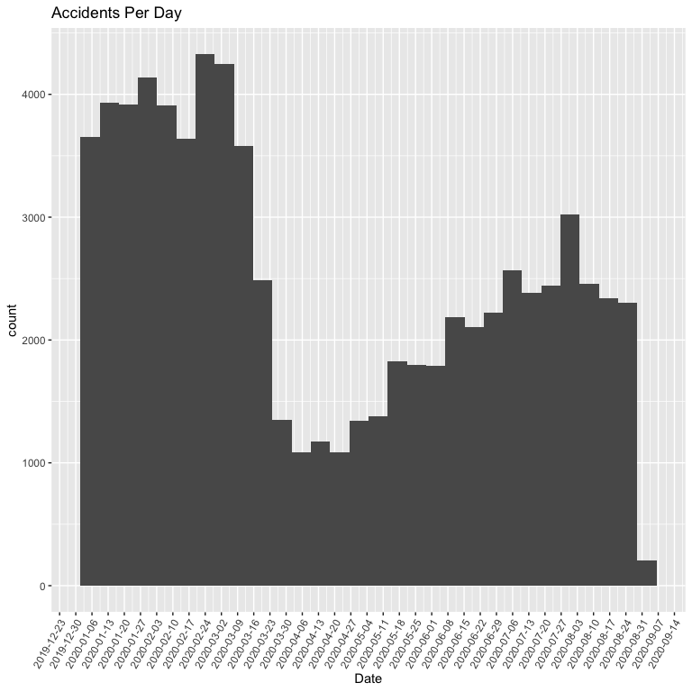

```r
ggplot(data = nyc_traffic_accidents, aes(x = CRASH.DATE)) +
geom_histogram() +
theme(axis.text.x=element_text(angle=60, hjust=1)) +
ggtitle("Accidents Per Day") +
scale_x_date(date_breaks = "weeks", date_labels = "%Y-%m-%d") +
xlab("Date")
```

### An Extension of ggplot ( )

First, I will show a pitfall of too much or improperly grouped data:

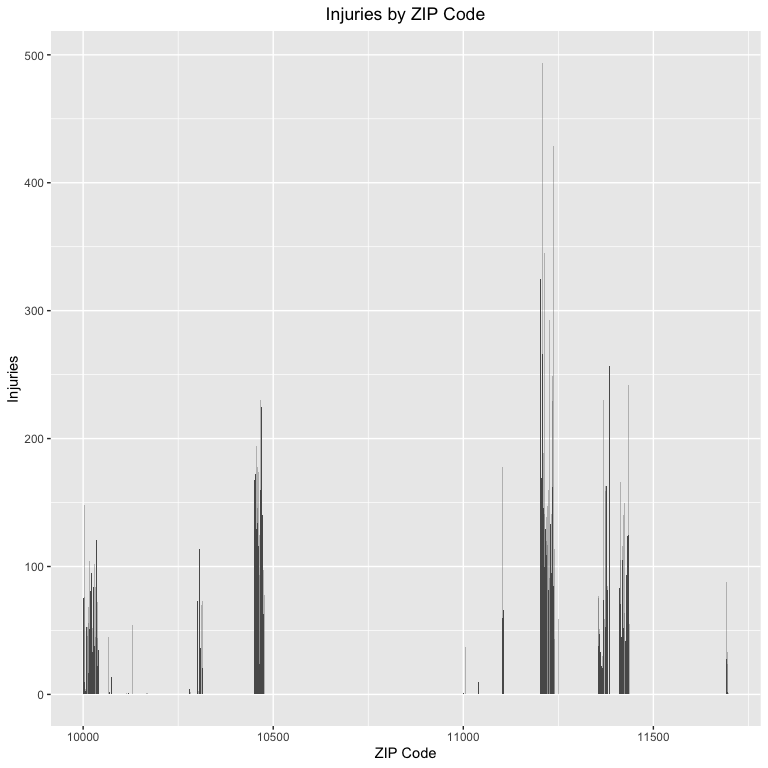

```r
ggplot(zip_injuries, aes(x=ZIP.CODE, y = injuries))+
  geom_col()+
  #geom_density(alpha=.2, fill = 'red')+
  ggtitle('Injuries by ZIP Code')+
  theme(plot.title = element_text(hjust = 0.5))+
  xlab('ZIP Code')+
  ylab('Injuries')
```

There are a few issues here. First, with the x representing ZIP.CODE, ggplot will sort the x-axis data based on the x-values, which are five-digit numbers that should not have any order in this plot. Second, there are nearly 200 entries to work with, which leads to a very busy plot.

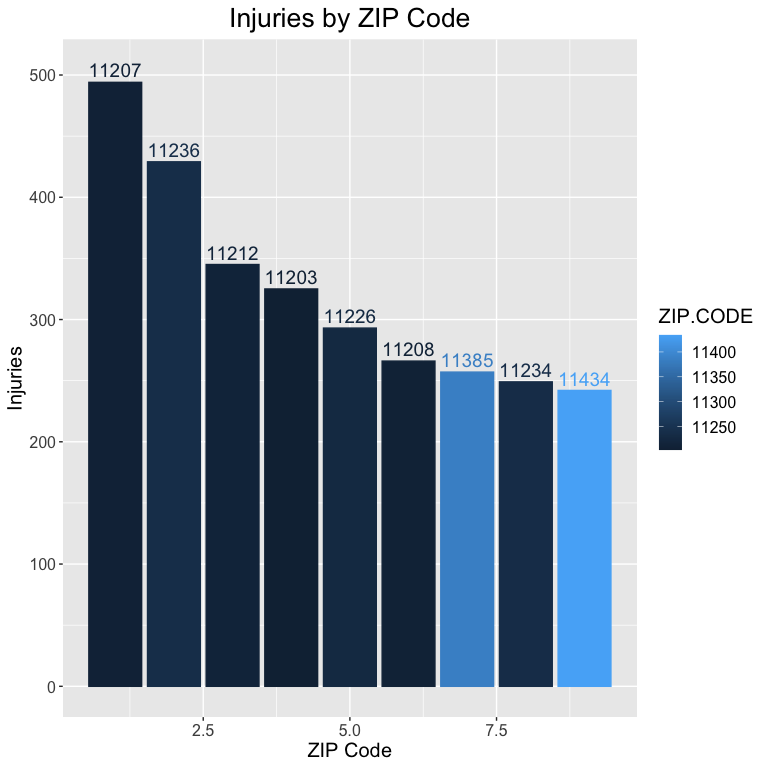

```r
zip_injuries <- zip_injuries %>% arrange(desc(injuries))
zip10 <- head(zip_injuries, n = 10)
zip10 <- na.omit(zip10)

zip10$idx <- as.numeric(row.names(zip10))

ggplot(zip10, aes(x=idx, y = injuries, color = ZIP.CODE))+
  geom_col(aes(fill = ZIP.CODE))+
  #geom_density(alpha=.2, fill = 'red')+
  ggtitle('Injuries by ZIP Code')+
  theme(plot.title = element_text(hjust = 0.5, size = 20))+
  theme(text = element_text(size = 15))+
  xlab('ZIP Code')+
  geom_text(
    label=zip10$ZIP.CODE,
    nudge_x = 0, nudge_y = 10,
    check_overlap = T,
    size = 5
  )+
  ylab('Injuries')
```